$\def \A \ensuremath{\mathbf{A}}$ $\def \b \ensuremath{\mathbf{b}}$ $\def \tA \ensuremath{\mathbf{A$^{T}$}}$ $\def \d \ensuremath{\mathbf{d}}$ $\def \e \ensuremath{\mathbf{e}}$ $\def \g \ensuremath{\mathbf{g}}$ $\def \I \ensuremath{\mathbf{I}}$ $\def \l \ensuremath{\mathbf{l}}$ $\def \M \ensuremath{\mathbf{M}}$ $\def \W \ensuremath{\mathbf{W}}$ $\def \y \ensuremath{\mathbf{y}}$ $\def \Y \ensuremath{\mathbf{Y}}$ $\def \X \ensuremath{\mathbf{X}}$ $\def \x \ensuremath{\mathbf{x}}$ $\def \tx \ensuremath{\mathbf{x$^{T}$}}$ $\def \z \ensuremath{\mathbf{z}}$ $\def \betab \ensuremath{\boldsymbol{\beta}}$ $\def \Omegab \ensuremath{\boldsymbol{\Omega}}$ $\def \pib \ensuremath{\boldsymbol{\pi}}$ $\def \thetab \ensuremath{\boldsymbol{\theta}}$ $\def \epsilonb \ensuremath{\boldsymbol{\epsilon}}$

# MCMC

Naim Rashid

2/7/2019

# 1 Introduction

In the previous lecture we discussed Monte Carlo Integration (MCI), where we drew samples from some target distribution $f$ in order to approximate the integral $\int h(\x)f(\x)d\x$. We also discussed ways to sample from an alternative density $g$ to reduce the variance of the standard MC estimator via importance sampling. This could be applied even when the target density $f$ cannot be sampled from and is only known up to a multiplicative proportionality constant.

Importance sampling can bring enormous gains with a good choice of $g$ by oversampling the “important” regions of the integrand, making an otherwise unfeasible problem amenable to MCI. It can also backfire with a bad choice of $g$ , yielding an estimate with infinite variance when simple Monte Carlo would have had a finite variance.

In our discussion of importance sampling, we were focused on integration. But what if need to directly obtain samples from a target distribution $f$ when no software/method is available to do so? This is common in Bayesian applications where sampling from some posterior distribution is required but is not easy to do (the exception is when conjugate priors are used). The ability to sample exactly (or approximately) from $f$ can also be helpful for applying MCI.

We will see later in this lecture that Markov Chain Monte Carlo (MCMC) approaches in particular may be preferable in cases where the dimension of the integral starts to become very large. We will discuss the relative pro’s and cons of each approach introduced below, motivated by our Poisson GLMM example from the previous lecture.

# 2 Motivating Example: MCEM-based estimation of the Poisson GLMM example

Let’s assume that we wish to utilize MCEM to fit the Poisson GLMM from the previous lecture. If we recall, the likelihood can be written as the following:

$$L(\boldsymbol{\beta}, \sigma^2_{\gamma} | \boldsymbol{y}) = \prod_{i = 1}^{22}\int \left[f(\boldsymbol{y}_{i} | \boldsymbol{\lambda}_{i})\phi(\gamma_i| 0, \sigma^2_{\gamma}) \right] d\gamma_i$$

where $f(\boldsymbol{y}_{i} | \boldsymbol{\lambda}_{i}) = \prod_{j = 1}^5 f(y_{ij} | \lambda_{ij})$, $f(y_{ij} | \lambda_{ij})$ is the Poisson PMF with mean $\lambda_{ij}$ for the $i$th patient in the $j$th month, $\gamma_i$ is the unobserved subject-level random effect, $\log(\lambda_{ij}) = \boldsymbol{x}_{ij}\boldsymbol{\beta} + \gamma_i$, and $\phi(\gamma_i| 0, \sigma^2_{\gamma}) \sim N(0,\sigma^2_{\gamma})$. Here $\boldsymbol{x}_{ij} = (1, j)$ with corresponding $\boldsymbol{\beta} = (\beta_0,\beta_1)^T$, where $\beta_0$ is the population intercept $\beta_1$ is the regression coefficient for month. Also, $\boldsymbol{y} = (\boldsymbol{y}_1^T,\ldots,\boldsymbol{y}_n^T)^T$ is the vector of all observations in the study, $\boldsymbol{y}_i$ is $5\times 1$ vector of words recalled in each month for subject $i$, $\boldsymbol{\lambda}_i = (\lambda_{i1},\ldots, \lambda_{i5})$,and $\boldsymbol{\gamma} = (\gamma_1,\ldots,\gamma_{22})$.

## 2.1 Complete Data Log Likelihood

If we assume $\boldsymbol{\gamma}$ was known, then we could write the CDLL as

$$\begin{align}
\log L_c(\boldsymbol{\beta}, \sigma^2_{\gamma} | \boldsymbol{y}, \boldsymbol{\gamma}) &= \log\left(\prod_{i = 1}^{22} f(\boldsymbol{y_{i}} | \boldsymbol{\lambda}_{i})\phi(\gamma_i| 0, \sigma^2_{\gamma})\right)\\
&=\sum_{i = 1}^{22} \log f(\boldsymbol{y}_{i} | \boldsymbol{\lambda}_{i}) + \log \phi(\gamma_i| 0, \sigma^2_{\gamma})\\
\end{align}$$

where $\log f(\boldsymbol{y}_{i} | \boldsymbol{\lambda}_{i}) = \sum_{j = 1}^{5}\log f(y_{ij} | \lambda_{ij})$.

## 2.2 Q-function

Given this, the Q-function at step $t$ can we written as the following:

$$\begin{align}
Q(\boldsymbol{\theta}|\boldsymbol{\theta}^{(t)}) &= E[\log L_c(\boldsymbol{\beta}, \sigma^2_{\gamma} | \y, \boldsymbol{\gamma}) | \boldsymbol{y}_o, \boldsymbol{\theta}^{(t)}]\\
&=\sum_{i = 1}^{22} \int \left[\log f(\boldsymbol{y}_{i} | \boldsymbol{\lambda}_{i}) + \log \phi(\gamma_i| 0, \sigma^2_{\gamma})\right]f(\gamma_i | \boldsymbol{y}_o, \boldsymbol{\theta}^{(t)})d\gamma_i
\end{align}$$

where $f(\gamma_i | \boldsymbol{y}_o, \boldsymbol{\theta}^{(t)})$ is the conditional expectation for $\gamma_i$ given the observed data and current parameter estimates. This density has the following form

$$\begin{align}
f(\gamma_i | \boldsymbol{y}_o, \boldsymbol{\theta}^{(t)}) &= \frac{f(\gamma_i, \boldsymbol{y}_o| \boldsymbol{\theta}^{(t)})}{f( \boldsymbol{y}_o| \boldsymbol{\theta}^{(t)})}\\
&=\frac{f(\boldsymbol{y}_o| \gamma_i ,\boldsymbol{\theta}^{(t)})f(\gamma_i |\boldsymbol{\theta}^{(t)})}{\int f(\boldsymbol{y}_o| \gamma_i ,\boldsymbol{\theta}^{(t)})f(\gamma_i |\boldsymbol{\theta}^{(t)}) d\gamma_i}\\
&=\frac{f(\boldsymbol{y}_{i} | \boldsymbol{\lambda}_{i}^{(t)})\phi(\gamma_i| 0, (\sigma^2_{\gamma})^{(t)})}{\int f(\boldsymbol{y}_{i} | \boldsymbol{\lambda}_{i}^{(t)})\phi(\gamma_i| 0, (\sigma^2_{\gamma})^{(t)}) d\gamma_i}\\
\end{align}$$

where $\boldsymbol{\lambda}_i^{(t)} = (\lambda_{i1}^{(t)},\ldots, \lambda_{i5}^{(t)})$ and $\log(\lambda_{ij}^{(t)}) = \boldsymbol{x}_{ij}^T\boldsymbol{\beta}^{(t)} + \gamma_i$. For a given subject $i$, we are evaluating a one-dimensional integral with respect to $\gamma_i$ to evaluate the Q-function. Therefore, methods from the prior section may be computationally feasible to apply. However, the denominator of the conditional density for $\gamma_i$ above also includes an integral.

This “normalizing constant” is exactly the (marginal) likelihood function given earlier for the $i$th subject, where we are integrating out the random effect $\gamma_i$. The joint density $f(\gamma_i, \boldsymbol{y}_o| \boldsymbol{\theta}^{(t)}) = f(\boldsymbol{y}_{i} | \boldsymbol{\lambda}_{i}^{(t)})\phi(\gamma_i| 0, (\sigma^2_{\gamma})^{(t)})$ in the numerator is easily evaluable assuming $\gamma_i$ is known. However, sampling from $f(\gamma_i | \boldsymbol{y}_o, \boldsymbol{\theta}^{(t)})$ is not straight-forward, as no standard statistical software is available to directly sample from this distribution.

## 2.3 Importance Sampling Implementation

For these reasons we can utilize importance sampling with standardized weights to approximate this integral, as discussed in the last lecture. This takes care of the normalizing constant during integration, avoiding having to evaluate it separately to compute the expectation. We should choose $g$ such that it is also easy to sample from. For low-dimensional integrals, we could use the Laplace approximation of AGQ to approximate this integral, but would not be scalable to higher dimensions.

That is, we can approximate the Q-function with respect to subject $i$ such that

$$\begin{align}
Q_i(\boldsymbol{\theta}|\boldsymbol{\theta}^{(t)}) &= \int \left[\log f(\boldsymbol{y}_{i} | \boldsymbol{\lambda}_{i}) + \log\phi(\gamma_i| 0, \sigma^2_{\gamma})\right]f(\gamma_i | \boldsymbol{y}_o, \boldsymbol{\theta}^{(t)})d\gamma_i\\
&= \int \left[\log f(\boldsymbol{y}_{i} | \boldsymbol{\lambda}_{i}) + \log\phi(\gamma_i| 0, \sigma^2_{\gamma})\right]\frac{f(\gamma_i | \boldsymbol{y}_o, \boldsymbol{\theta}^{(t)})}{g(\gamma_i)}g(\gamma_i)d\gamma_i\\
&= \int \left[\sum_{j = 1}^{5}\log f(y_{ij} | \lambda_{ij}) + \log\phi(\gamma_i| 0, \sigma^2_{\gamma})\right]\frac{f(\gamma_i | \boldsymbol{y}_o, \boldsymbol{\theta}^{(t)})}{g(\gamma_i)}g(\gamma_i)d\gamma_i\\
&\approx \sum_{k = 1}^M\left[\sum_{j = 1}^{5}\log f(y_{ij} | \lambda_{ijk}) + \log \phi(X_k| 0, \sigma^2_{\gamma})\right]w(\boldsymbol{X}_k)
\end{align}$$

where $w(\boldsymbol{X}_k) = \frac{ w^*(\boldsymbol{X}_k)}{\sum_{k = 1}^M w^*(\boldsymbol{X}_k)}$, $w^*(\boldsymbol{X}_k) = \frac{\prod_{j = 1}^{5}f(y_{ij} | \lambda_{ijk}^{(t)})\phi(X_k| 0, (\sigma^2_{\gamma})^{(t)})}{g(\boldsymbol{X}_k)}$, $\log(\lambda_{ijk}) = \boldsymbol{x}_{ij}^T\boldsymbol{\beta} + X_k$, and $X_1,\ldots,\X_M$ are iid draws from some importance sampling distribution $g$. It should be noted that in the normalizing constant depends on $\boldsymbol{\theta}^{(t)}$ and not $\boldsymbol{\theta}$, and therefore is irrelevant in the M-step. It should also be noted that since we are using the standardized weights, we no longer divide the approximation by $M$.

For the M-step, we can use again off-the shelf maximization routines for the above approximation for the Q-function.

## 2.4 Choice of Importance Function

The question now is what is a suitable choice for $g$? Similar to AGQ and the Laplace Approximation, we may choose to sample from a Student t importance density whose mean and variance match the mode and curvature of $f(\gamma_i \boldsymbol{y}_o| \boldsymbol{\theta}^{(t)})$. [Additional detail can be found here](https://www.jstor.org/stable/2680750?seq=1#metadata_info_tab_contents). In general, there may not always be a clear choice of $g$, which is critical to the success of importance sampling.

As the dimension increases, MCI and importance sampling retains its advantage over the quadrature-based approaches. However, the choice between importance sampling and alternative approaches for evaluating the conditional expectation above may vary depending on the problem. We will discuss these alternatives and how to choose between them in this lecture. More generally, these alternative approaches provide a means to sample exactly or approximately from distributions where it is difficult to do so, such as from $f(\gamma_i | \boldsymbol{y}_o, \boldsymbol{\theta}^{(t)})$.

# 3 Exact/Direct sampling

In the above example we find that we do not have a clear means to generate samples from the conditional density of $\gamma_i$. We know that $f(\gamma_i | \boldsymbol{y}_o, \boldsymbol{\theta}^{(t)})$ is known up to a proportionality constant, but we do not have a clear means to sample from this distribution to allow for MCI to be applied given these samples.

One way to do this is to use a category of methods called “direct” or “exact” sampling, where one can directly sample from the target distribution $f$ rather than avoid sampling from it completely (importance sampling), or approximately sampling from it (MCMC). We will show for the two classes of methods in this section, Rejection Sampling and Adaptive Rejection Sampling, that the samples drawn here are **independent**. Using Rejection Sampling, we can generate samples from any density $f$ as long as we have a closed and evaluable form of $f$.

## 3.1 Rejection Sampling

If the target distribution $f(x)$ can be calculated, at least up to a proportionality constant, then we can use Rejection Sampling to directly obtain a random draw from the target distribution. The general idea behind Rejection Sampling is that we first sample from an alternative distribution $g$ to generate **candidate samples**. We then correct for the fact that these samples came from another distribution through the random rejection of some of the samples, effectively correcting the original sampling probabilities. Importance sampling in contrast directly weights samples from $g$ during the computation of the integral, rather than attempting to directly simulate samples from $f$ itself. Rejection sampling therefore selects a subsample of those samples originally drawn from $g$, whereas importance sampling uses every draw from $g$ and weights their contribution.

Let us assume that we can calculate $g(x)$ easily and denote $e(\cdot)$ as the “envelope” function such that
$$e(x) = \frac{g(x)}{\alpha} > f(x)$$
for all $x$ where $f(x) > 0$. Here $\alpha \leq 1$ and is a constant. That is, for all regions where $f(x)$ is nonzero, $g(x)$ is greater than or equal to $f(x)$ (hence the term “envelope”).

Then, we implement Rejection Sampling using the following procedure:

1. Sample the candidate $Y ∼ g$
2. Sample $U ∼ U(0, 1)$
3. Reject the candidate sample $Y$ if $U > f(Y)/e(Y)$. Return to step 1.
4. If $U < f(Y)/e(Y)$, keep Y. Set X = Y, and consider X to be an element of the random sample from the target distribution . Return to step 1 until you have accumulated a sample of the desired size.

The retained draws then represent an **i.i.d. sample** from the target distribution $f$. Here, $\alpha$ can be interpreted as the expected proportion of candidates that are accepted. We often repeat the steps above until we obtain the desired number of samples. The total number of candidate draws needed to obtain that number of samples depends on how efficient the algorithm is in accepting samples (mediated by $\alpha$). Clearly, this is highly dependent on the choice of $e$. We will address how best to select $e$ later on in this section.

### 3.1.1 Why does this work?

A formal proof is given in GH 6.2.3, but we illustrate this graphically below. The rejection rule in Step 3 above is equivalent to sampling $U\rvert y \sim Unif(0, e(y))$ and keeping the value $y$ if $U < f(y)$ (see figure below from GH Fig 6.1)

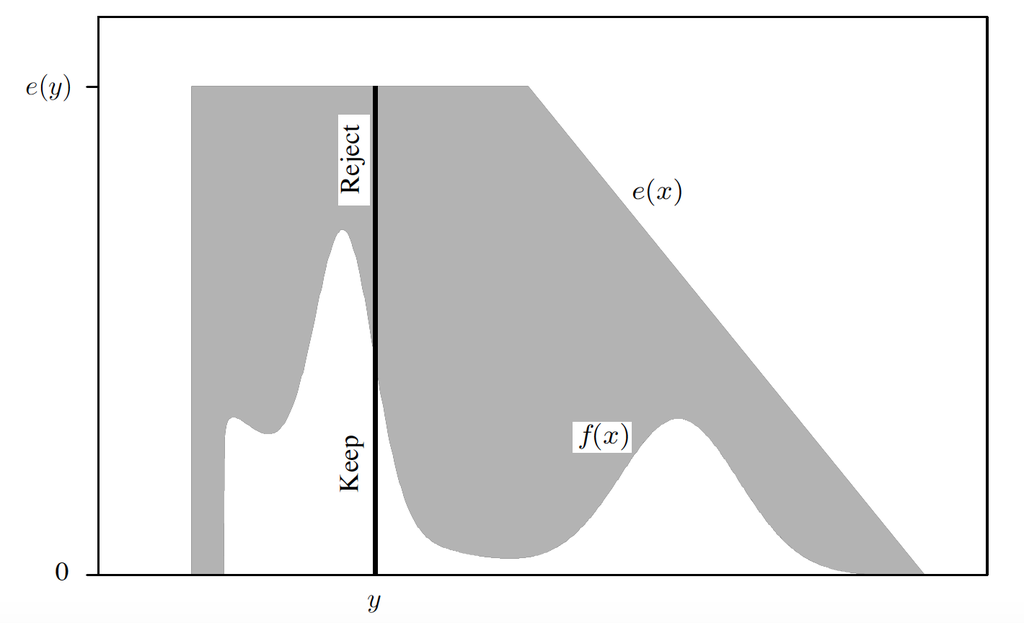

Illustration of Rejection Sampling.

Let’s suppose that our particular draw $y$ is at the vertical bar along the support of the target density (x-axis of fig). Then imagine sampling $U|Y = y$ uniformly along the vertical bar. In step 3, we reject this draw with probability proportional to the bar length above $f(y)$ relative to the overall length of the bar ($e(y)$). Therefore, one can view Rejection Sampling as sampling uniformly from the two-dimensional region under the curve $e$ and then throwing away any draws falling above $f$ and below $e$. Since sampling from $f$ is equivalent to sampling uniformly from the two-dimensional region under the curve labeled $f(x)$ and then ignoring the vertical coordinate, Rejection Sampling provides draws exactly from $f$.

In other words, this procedure is equivalent to first randomly selecting a point from the x-axis above by sampling from $g$, then drawing a sample $U$ from $U(0, e(y))$ along the y-axis. If $f(y)<U<e(y)$ then we reject, otherwise we keep the sample. In this manner, we are able to obtain an iid sample that is exactly from the target distribution $f$.

The shaded region in the figure above $f$ and below $e$ indicates the waste. Intuitively, a candidate draw is likely to be rejected when $e(y) >> f (y)$, whereas envelopes is only slightly bigger than $f$ everywhere produce fewer rejected draws, corresponding to $\alpha$ values near 1.

What if $f$ is only known up to a proportionality constant $c$ such as in our MCEM example above? For example, if we define $q(x) = f (x)/c$, where c is unknown, we can find an envelope $e$ such that $e(x) \geq q(x)$ for all $x$ for which $q(x) > 0$. A draw $Y = y$ is then rejected when $U > q(y)/e(y)$. This approach is similar to what we have described before, and we can show that that $c$ cancels out in the original proof in GH equation 6.2.3 when $f$ is replaced by $q$. That is, we can similarly apply Rejection Sampling to this case. The proportion of kept draws is $\alpha/c$.

Multivariate targets can also be sampled using Rejection Sampling, provided that a suitable multivariate envelope can be constructed.

### 3.1.2 Selecting an envelope function

To produce an envelope, we must know enough about the target function to effectively bound it. This may require optimization, or a clever approximation to $f$ or $q$ in order to ensure that the envelope $e$ can be chosen so that it exceeds $f$ everywhere. In general, good Rejection Sampling envelopes have three properties:

1. They are easily constructed or confirmed to exceed the target everywhere
2. They are easy to sample from
3. They generate few rejected draws.

Clearly this is not an exact science, and how best to do this will vary by problem. This is one of the downsides of Rejection Sampling, where sometimes determining the best envelope function can be difficult or time consuming. In some examples this step is simple, but that will not case in all situations.

## 3.2 Adaptive Rejection Sampling

Adaptive Rejection Sampling is an automatic procedure to determine envelopes for the specific case where one has a continuous, differentiable, log-concave target density that one would like to sample from. Here, the envelope and another function called the “squeezing function” are iteratively updated with the generation of samples. In this approach the amount of waste and the frequency with which $f$ must be evaluated both shrink as iterations increase. The implementation is more complicated than that of regular Rejection Sampling. A tangent-based and derivative-free implementation of adaptive Rejection Sampling are available, the latter of which has been incorporated into the popular WinBUGS often used in Bayesian analyses. We do not go into further detail here and direct students to GH 6.2.3.2 for more detail.

## 3.3 Example: Sampling from a posterior distribution

Let’s suppose we have 10 independent observations from GH Example 6.2 are observed from the model $X_i| \lambda \sim$ Poisson($\lambda$). Let us assume a lognormal prior distribution for $\lambda$, where $\log(\lambda) \sim N(\log(4), 0.5^2)$. Here, we want to sample from the posterior distribution of $\lambda$ given the data.

Let’s start with a histogram of the data and calculating $\bar{x}$ below.

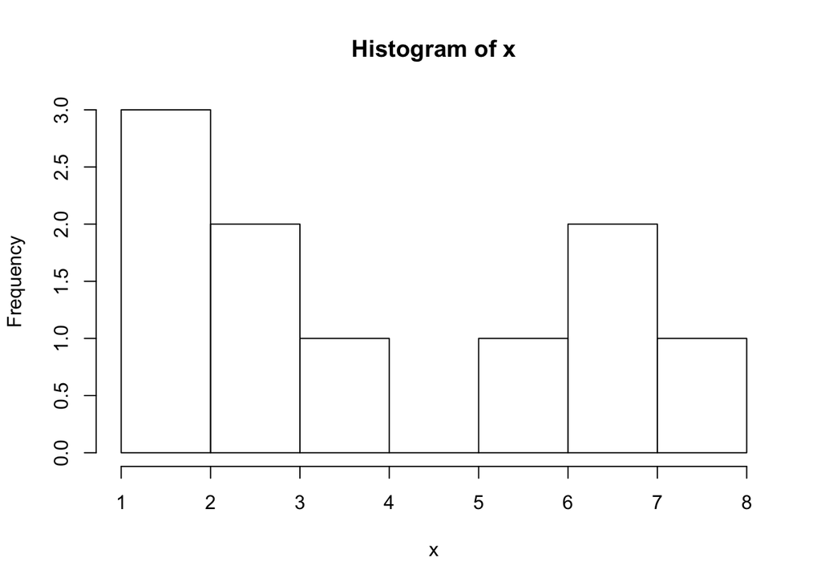

```r
# vector of observations
x = c(8, 3, 4, 3, 1, 7, 2, 6, 2, 7)

# make histogram
hist(x)
```

```r
# print the mean of x
print(mean(x))
```

```
## [1] 4.3
```

Denote the likelihood as $L(\lambda|\boldsymbol{x})$ and the lognormal prior for $\lambda$ as $f(\lambda)$. We know that $\hat{\lambda} = \bar{x}$ maximizes the likelihood $L(\lambda|\boldsymbol{x})$ with respect to $\lambda$. As a result, the unnormalized posterior, $q(\lambda|\boldsymbol{x}) = f(\lambda)L(\lambda|\boldsymbol{x})$ is bounded above by the function $e(\lambda) = f (\lambda)L(4.3|\boldsymbol{x})$. We can show this visually below:

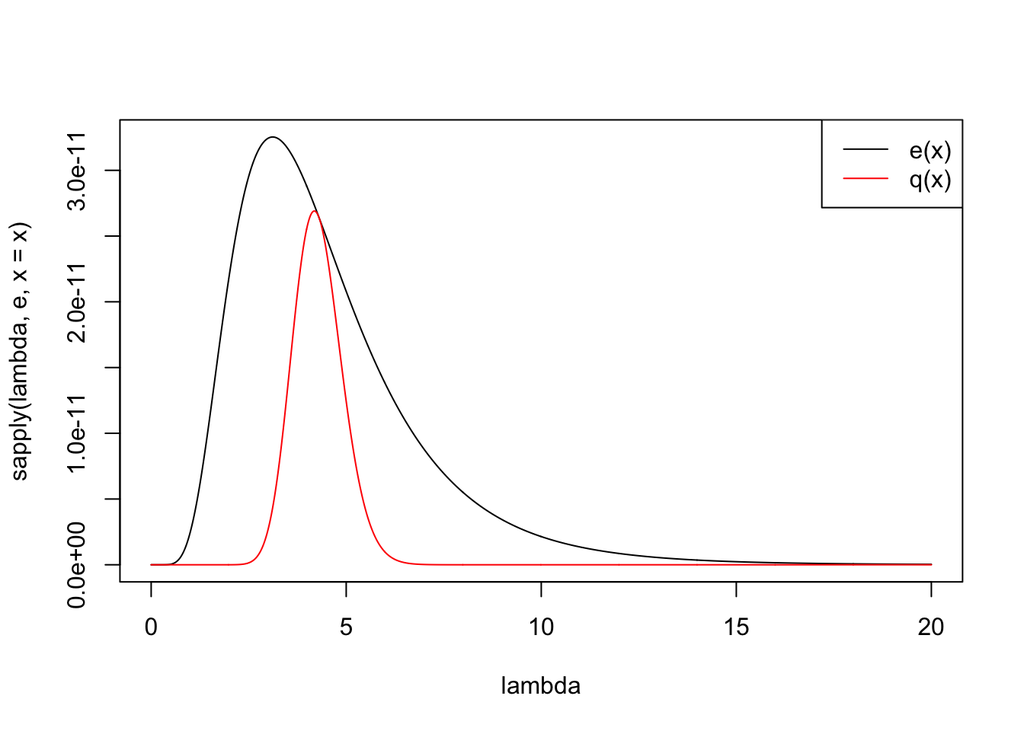

```r
# unnormalized posterior function
q = function(lambda, x) {
  prod(dpois(x, lambda = lambda)) * dlnorm(x = lambda,
                                           meanlog = log(4),
                                           sdlog = 0.5)
}

# envelope function
e = function(lambda, x) {
  # fixing lambda at the mean of x in the likelihood
  prod(dpois(x, lambda = mean(x))) * dlnorm(x = lambda,
                                            meanlog = log(4),
                                            sdlog = 0.5)
}

# plot setup
lambda = seq(0, 20, , 1000)

# plot the envelope
plot(lambda, sapply(lambda, e, x = x), col = "black", type = 'l')

# add plot for q
lines(lambda, sapply(lambda, q, x = x), col = "red")

# add a legend
legend(
  c("e(x)", "q(x)"),
  col = c(1, 2),
  lty = c(1, 1) ,
  x = "topright"
)
```

One nice thing to note about the chosen envelope is that the prior is proportional to $e$ (likelihood fixed at the mean is now a constant). Therefore, $g$ is clearly is the lognormal prior (refer to definition of $g$ and $e$ from the setup for Rejection Sampling).

So, we can start the Rejection Sampling algorithm by first sampling $\lambda_i$ from the lognormal prior and $U_i$ from a standard uniform distribution. Then, following the steps for the Rejection Sampling algorithm laid out earlier, we have that $\lambda_i$ is kept if $U_i < \frac{q(\lambda_i|\boldsymbol{x})}{e(\lambda_i)} = \frac{L(\lambda_i|\boldsymbol{x})}{L(4.3|\boldsymbol{x})}$:

```r
set.seed(100)
# specify how many samples to keep
M = 100

# specify max number of iterations in case alpha is low (can increase later if needed)
maxit = M * 10 ^ 4

# specify vector to hold accepted samples
posterior_lambda = rep(0, M)

# start rejection algorithm
i = index = 1
while (i <= M & index < maxit) {
  # sample from lognormal prior
  lambdai = rlnorm(1, meanlog = log(4), sdlog = 0.5)

  # sample Ui from standard uniform
  Ui = runif(1)

  # calculate ratio
  Lq = prod(dpois(x, lambda = lambdai))
  Le = prod(dpois(x, lambda = mean(x)))
  r = Lq / Le

  # if Step 3 condition met, save sample
  if (Ui < r) {
    posterior_lambda[i] = lambdai
    # update iterator
    i = i + 1
  }

  # keep track of total number of samples drawn
  index = index + 1
}

# acceptance rate
print(M / index)
```

```
## [1] 0.2583979
```

Although not terribly efficient with an acceptance rate of about 26%, it is relatively easy to implement.

Let’s make a histogram of the samples from the posterior:

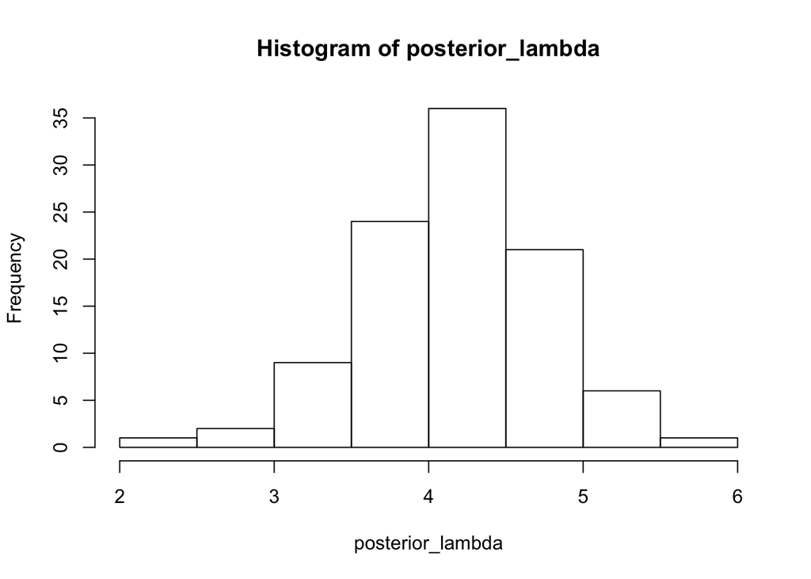

```r
hist(posterior_lambda )
```

## 3.4 Pros and cons of Rejection Sampling

So, to summarize we have the following advantages and disadvantages of Rejection Sampling

- Pros
  - Sample is truly iid from target density $f$, no approximation and samples are independent
- Cons
  - Designing a good envelope function $e$ may not be straightforward or easy to do
  - Many candidates draws may be needed to obtain a sample of size $M$, depends on choice of $e$
  - As the dimension of the integral groups, the above problem gets worse (acceptance rate is lower)

Regarding the last point above, it becomes harder in general to accept multivariate candidate draws in higher dimensions. One way to think about this is to envision a multivariate version of the prior example. The envelope function would be defined similarly, except that it would be multivariate, and that we would maximize over a multivariate space in the new likelihood function rather than a univariate one. We would then fix the mean of the likelihood to this MLE.

Ideally, each candidate draw, say $\boldsymbol{X}_i$ from the multivariate prior $g$ in this case would be close to the MLE, implying that $f(\boldsymbol{X}_i)$ is close to $e(\boldsymbol{X}_i)$, leading to likely acceptance of this sample. As we increase the dimension to say $d = 10$, the probability that a drawn vector will be close to the MLE in every dimension becomes harder and harder.

In higher dimensional settings we will see that the MCMC approaches discussed in the second half of this lecture are more efficient relative to Rejection Sampling.

## 3.5 Application to the MCEM Example

We can similarly apply Rejection Sampling to draw iid samples from the target density $f(\gamma_i | \boldsymbol{y}_o, \boldsymbol{\theta}^{(t)}) = f(\boldsymbol{y}_{i} | \boldsymbol{\lambda}_{i}^{(t)}),\phi(\gamma_i| 0, (\sigma^2_{\gamma})^{(t)})$. The question here is what is the best envelope function to use.

Similar to the previous example, one obvious option is simply $e(\gamma_i | \boldsymbol{y}_o, \boldsymbol{\theta}^{(t)}) = f(\boldsymbol{y}_{i} | \boldsymbol{\lambda}_{i}^{*(t)})\phi(\gamma_i| 0, \sigma^2_{\gamma})$, where $\boldsymbol{\lambda}_i^{*(t)} = (\lambda_{i1}^{*(t)},\ldots, \lambda_{i5}^{*(t)})$, $\log(\lambda_{ij}^{*(t)}) = \boldsymbol{x}_{ij}^T\boldsymbol{\beta}^{(t)} + \hat{\gamma}_i$ and $\hat{\gamma}_i$ is maximizer of $f(\boldsymbol{y}_{i} | \boldsymbol{\lambda}_{i}^{(t)})$ with respect to $\gamma_i$. This can be done quite easily within the GLM framework, as we will show below.

Then similar to before, our proposal density $g$ can be $\phi(\gamma_i| 0, (\sigma^2_{\gamma})^{(t)})$. We also draw $U$ separately from a standard uniform distribution. Then, candidate $X$ drawn from $g$ is kept if $U < \frac{q(\gamma_i | \boldsymbol{y}_o, \boldsymbol{\theta}^{(t)})}{e(\gamma_i | \boldsymbol{y}_o, \boldsymbol{\theta}^{(t)})} = \frac{f(\boldsymbol{y}_{i} | \boldsymbol{\lambda}_{i}^{(t)})}{f(\boldsymbol{y}_{i} | \boldsymbol{\lambda}_{i}^{*(t)})}$, where $\phi(\gamma_i| 0, (\sigma^2_{\gamma})^{(t)})$ cancels out in the numerator and denominator.

We will use this sampling step to perform MCI in the E-step. In contrast to the importance sampling setup given earlier, we can approximate the Q-function in the $i^{th}$ sample using

$$\begin{align}
Q_i(\boldsymbol{\theta}|\boldsymbol{\theta}^{(t)}) &= \int \left[\log (f(\boldsymbol{y}_{i} | \boldsymbol{\lambda}_{i}) + \log\left(\phi(\gamma_i| 0, \sigma^2_{\gamma})\right)\right]f(\gamma_i | \boldsymbol{y}_o, \boldsymbol{\theta}^{(t)})d\gamma_i\\
&= \int \left[\sum_{j = 1}^{5}\log(f(y_{ij} | \lambda_{ij}) + \log\left(\phi(\gamma_i| 0, \sigma^2_{\gamma})\right)\right]f(\gamma_i | \boldsymbol{y}_o, \boldsymbol{\theta}^{(t)})d\gamma_i\\
&\approx \frac{1}{M}\sum_{k = 1}^M\left[\sum_{j = 1}^{5}\log\left(f(y_{ij} | \lambda_{ijk})\right) + \log\left(\phi(X_k| 0, \sigma^2_{\gamma})\right)\right]
\end{align}$$

since we are now able to draw iid samples from the posterior using Rejection Sampling. Here, $\log(\lambda_{ijk}) = \boldsymbol{x}_{ij}^T\boldsymbol{\beta} + X_k$, and $X_1,\ldots,X_M$ are iid draws from the target density $f(\gamma_i | \boldsymbol{y}_o, \boldsymbol{\theta}^{(t)})$. Then, we can carry out the M step using standard optimization routines, for example, using NR or BFGS from our optimization lecture. In the following section, we detail this approach.

### 3.5.1 Implementing the E-step Rejection sampler

First, let’s set up the rejection sampler. We do this first for the $i$the subject, then write a second function that loops over all subjects that calls this function. Can you think of a way to vectorize this function? For more applications, best to rewrite in Rcpp for best performance.

```r
## function for Rejection Sampling in the MCEM E-step for subject i
# yi:       a 5 x 1 vector containing the monthly observations for sample i
# xi:       a 5 x 2 matrix pertaining to the intercept and longitudinal month value for each subject (it is the same for each subject, 1:5)
# M:        the total number of iid samples desired from the posterior
# maxit:    the max number of iterations (to prevent runaway looping)
# betat:    the estimate for beta at EM iteration t
# s2gammat: the estimate for s2gamma at EM iteration t
## Returns a list object with accepted samples and the acceptance rate

rejection.sample.gamma.posterior.i = function(yi, xi = cbind(rep(1,5), 1:5), M, maxit, betat, s2gammat, trace = 0) {

  ## envelope function setup, done once
  # obtain gamma_hat to create the envelope function, optimizing Likelihood wrt gammai
  # can use any optimization routine, here using IRLS holding XB fixed as an offset
  # log(lambda_i) = X%*%beta_t + gamma_i --> fix X and beta_t, treat gamma_i as coefficient
  gamma_hat = glm(yi ~ 1, family = poisson(),
                  offset = xi %*% beta)$coef

  # calculate lambda values for rejection ratio denominator
  lambda_star = exp(xi %*% beta + gamma_hat)

  # calculate rejection ratio denominator
  Le = prod(dpois(yi, lambda = lambda_star))

  ## specify vector to hold samples
  posterior_gammai = rep(0, M)

  ## start rejection sampler
  m = index = 1
  while (m <= M & index < maxit) {

    # sample from normal prior (proposal density here)
    gammai = rnorm(1, 0, sqrt(s2gammat))

    # calculate lambda values for rejection ratio numerator
    lambdai = exp(xi %*% beta + gammai)

    # calculate ratio numerator
    Lq = prod(dpois(yi, lambda = lambdai))

    # calculate ratio
    r = Lq / Le

    # sample Ui from standard uniform
    U = runif(1)

    # if step 3 met, save sample
    if (U < r) {
      posterior_gammai[m] = gammai

      # update num current acceptances
      m = m + 1
    }

    # keep track of total number of samples drawn
    index = index + 1
  }

  ## acceptance rate
  if (trace > 0)
    print(M / index)

  ## return accepted samples and accepted rate in a list
  return(list(gammai = posterior_gammai, ar = M / index))
}
```

As you can imagine, this can be quite slow, especially for large M. Since the rejection sampler is not a recursive method, we could also vectorize the above (can you guess how?).

Below is the wrapper function that loops over all subjects.

```r
# data: is the main data.table object
# other arguments same as above

## Returns rejection samples matrix (n x M)

rejection.sample.gamma.posterior.all = function(data,
                                                M,
                                                maxit,
                                                betat,
                                                s2gammat,
                                                trace = 0) {
  ## get n, total number of subjects
  n = length(unique(data[,subject]))

  # create n x M matrix to hold rejection samples for each subject
  rejection.samples = matrix(NA,nrow = n, ncol = M)

  ## looping over n subjects
  for (i in 1:n) {

    if(trace > 0) print(i)

    # draw M samples from the posterior for gamma_i
    rejection.samples.i =
      rejection.sample.gamma.posterior.i(
        yi = data[subject == i, words],
        M = M,
        maxit = maxit,
        betat = betat,
        s2gammat = s2gammat,
        trace = trace
      )$gammai

    # save to matrix
    rejection.samples[i,] = rejection.samples.i

  }

  if(trace > 0) print("completed sampling")

  ## return matrix
  return(rejection.samples)

}
```

### 3.5.2 Other Helper Functions

We implement a function that calculated the Q-function for the $i$th subject, then make a second one that loops over all subjects. This is used to return the value of the Q-function in the E-step, given the estimates from the M-step and the observed data. We also use this function in the M-step as input to the Nelder-Mead algorithm as the objective function to be maximized.

I’ve left my first implementation using a for loop in the function below to better illustrate the method. Below that I’ve written a vectorized version that scales better with $M$ and is much faster.

```r
# datai:  observed data (alz) pertaining to the i'th subject
# gammai: M draws pertaining to gamma i
Qi = function(datai,
              xi = cbind(rep(1, 5), 1:5),
              betat,
              s2gammat,
              gammai) {
  # 5 x 1 vector
  yi = datai$words

  # get M
  M = length(gammai)

  # For each of the M draws, evaluate the integrand
  # using a for loop here (slower!)
  ##qi = 0
  ##for (m in 1:M) {
  ##  lambdai = exp(xi %*% betat + gammai[m])
  ##  qi = qi + sum(dpois(yi, lambda = lambdai, log = T)) +
  ##    dnorm(gammai[m],
  ##          mean = 0,
  ##          sd = sqrt(s2gammat),
  ##          log = T)
  ##}

  # now divide by M
  ##qi  = qi / M

  # Let use a vectorized version instead.
    # create 5 x M matrix, x_beta_mat
    # each column is xi %*% betat, just repeated
    x_beta_mat = xi %*% matrix(betat, nrow = length(betat), ncol = M)

    # create 5 x M matrix, x_beta_plus_gamma_mat
    # m'th column is xi %*% betat + gammai[m]
    x_beta_plus_gamma_mat = sweep(x_beta_mat, 2 , gammai, "+")

    # calculate lambda (5 x M matrix)
    lambdai = exp(x_beta_plus_gamma_mat)

    # calculate Q
    ymat = matrix(yi, nrow = length(yi), ncol = M)
    qi = sum(dpois(ymat, lambda = lambdai, log = T)) +
         sum(dnorm(gammai, mean = 0,sd = sqrt(s2gammat),log = T))

    # divide sum by M
    qi = qi / M

  ## return values
  return(qi)
}
```

Now here is the higher level function that loops over each subject.

```r
# Same parameters above except for the following one
# logs2gammat:  Indicates whether s2gammat is initially passed on the log scale.  If true, then indicates that s2gammat has to be back transformed to original scale in function.  This helps to avoid boundary issues during maximization when s2gamma estimates are close to zero and this transformation also maps to the real number line.

Q = function(data,
             betat,
             s2gammat,
             rejection.samples,
             logs2gammat = F) {
  # backtranform if maximizing s2gammat on log scale
  if (logs2gammat == T) {
    s2gammat = exp(s2gammat)
  }

  # initialize sum
  Q = 0

  # loop over subjects
  for (i in 1:22) {
    Q = Q + Qi(data[data$subject == i, ],
               betat = betat,
               s2gammat = s2gammat,
               gammai = rejection.samples[i, ])
  }

  # return
  return(Q)
}
```

### 3.5.3 Setup for the MCEM algorithm

Now that we have these helper functions, lets read in the data and set up everything for the EM algorithm

```r
## read in the data, convert to data.table
  library(data.table)
  alz = read.table("alzheimers.dat", header = T)
  alz = data.table(alz)

## set initial parameters
  # number of subjects
  n = length(unique(alz$subject))

  # relative convergence threshold
  tol = 10^-5

  # max number of iterations
  maxit = 100

  # initialize iteration counter, epsilon, qfunction value to avoid triggering while loop
  iter = 0
  eps = Inf
  qfunction = -10000 # using Qfunction for convergence


## starting values for beta/s2gamma

  # fixed effects, same as before
  beta = c(1.804, 0.165)

  # random intercept variance, same as before
  s2gamma =  0.000225 + .01


## set M = 10000 draws from posterior per observation in E-step
  M = 10000
```

### 3.5.4 Testing the Rejection Sampler

Let’s test out the Rejection Sampler on just the first sample, given the starting values:

```r
# run RS
test_sample = rejection.sample.gamma.posterior.i(
  yi = alz[subject == 1, words],
  M = M,
  maxit = maxit*M,
  betat = beta,
  s2gammat = s2gamma
)

# acceptance rate
print(test_sample$ar)
```

```
## [1] 0.07821727
```

```r
# mean
print(mean(test_sample$gammai))
```

```
## [1] 0.135868
```

```r
# variance
print(var(test_sample$gammai))
```

```
## [1] 0.006368196
```

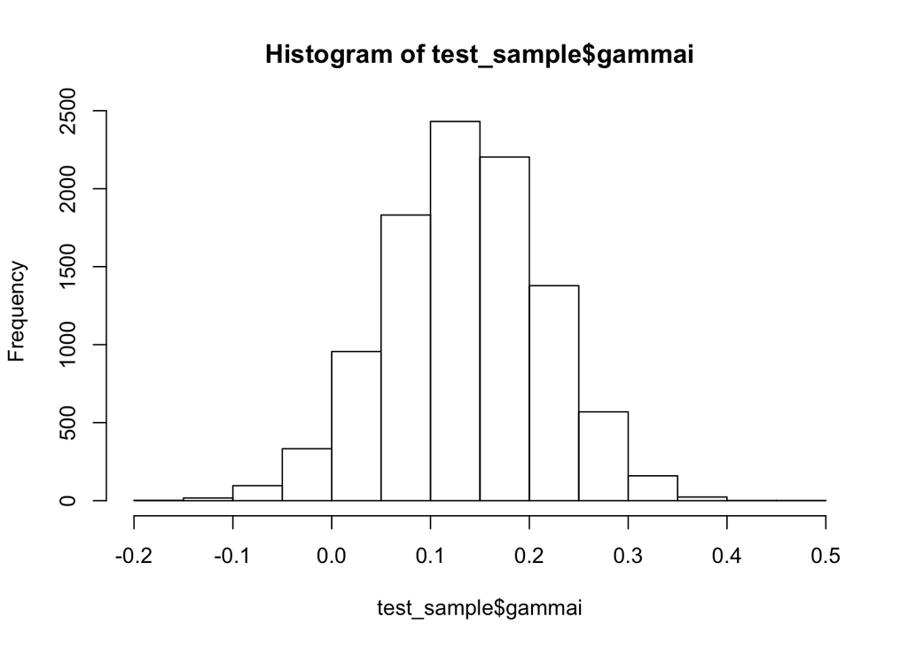

```r
#histogram
hist(test_sample$gammai)
```

### 3.5.5 Now run the MCEM algorithm

Now that thats out of the way, lets apply the MCEM algorithm.

```r
library(optimx)

start = Sys.time()
while(eps > tol & iter < maxit){

  ## save old qfunction
    qfunction0 = qfunction

  ## Begin E-step

    # update rejection.samples column with the new draws
    rejection.samples = rejection.sample.gamma.posterior.all(
      data = alz,
      M = M,
      maxit = 100 * M,
      betat = beta,
      s2gammat = s2gamma
    )

    ## evaluate  qfunction given drawn samples, current param estimates
    qfunction = Q(data = alz,
                  betat = beta,
                  s2gammat = s2gamma,
                  rejection.samples = rejection.samples
                )

  ## End E-step


  ## Calculate relative change in qfunction from prior iteration
    eps  = abs(qfunction - qfunction0) / abs(qfunction0)


  ## Start M-step : nelder mead
    fit = optimx(
      # initial values for the parameters
      par = c(beta, log(s2gamma)), # maximizing s2gamma on log scale!
      # Q function wrapper
      fn = function(x, data, rejection.samples){
            Q(data = alz,
              betat = x[1:length(beta)],
              s2gammat = x[length(beta)+1],
              rejection.samples = rejection.samples,
              logs2gammat = T # indicating s2gamma on log scale!
            )
        },
      method = "Nelder-Mead",
      data = data,
      rejection.samples = rejection.samples,
      control = list(
        trace = 0,
        maximize = T,
        abstol= tol
      )
    )

    # extract parameters
    beta = as.numeric(fit[1:length(beta)])
    s2gamma = as.numeric(fit[length(beta)+1])

    # remember to back transform s2gamma
    s2gamma = exp(s2gamma)

  ## End M-step


  ## update iterator
    iter = iter + 1
    if(iter == maxit) warning("Iteration limit reached without convergence")


  ## print out info to keep track
    cat(sprintf("Iter: %d Qf: %.3f s2gamma: %f beta0: %.3f beta0:%.3f eps:%f\n",iter, qfunction,s2gamma, beta[1],beta[2], eps))
}
```

```
## Maximizing -- use negfn and neggr
## Iter: 1 Qf: -326.641 s2gamma: 0.013281 beta0: 1.873 beta0:0.166 eps:0.967336
## Maximizing -- use negfn and neggr
## Iter: 2 Qf: -318.358 s2gamma: 0.019025 beta0: 1.862 beta0:0.166 eps:0.025358
## Maximizing -- use negfn and neggr
## Iter: 3 Qf: -315.868 s2gamma: 0.029183 beta0: 1.849 beta0:0.166 eps:0.007822
## Maximizing -- use negfn and neggr
## Iter: 4 Qf: -308.533 s2gamma: 0.048695 beta0: 1.832 beta0:0.166 eps:0.023222
## Maximizing -- use negfn and neggr
## Iter: 5 Qf: -296.458 s2gamma: 0.080599 beta0: 1.803 beta0:0.166 eps:0.039136
## Maximizing -- use negfn and neggr
## Iter: 6 Qf: -287.839 s2gamma: 0.118253 beta0: 1.781 beta0:0.166 eps:0.029074
## Maximizing -- use negfn and neggr
## Iter: 7 Qf: -271.519 s2gamma: 0.178989 beta0: 1.785 beta0:0.166 eps:0.056696
## Maximizing -- use negfn and neggr
## Iter: 8 Qf: -268.659 s2gamma: 0.209710 beta0: 1.788 beta0:0.166 eps:0.010537
## Maximizing -- use negfn and neggr
## Iter: 9 Qf: -268.588 s2gamma: 0.217591 beta0: 1.791 beta0:0.166 eps:0.000263
## Maximizing -- use negfn and neggr
## Iter: 10 Qf: -268.643 s2gamma: 0.219660 beta0: 1.793 beta0:0.166 eps:0.000204
## Maximizing -- use negfn and neggr
## Iter: 11 Qf: -268.657 s2gamma: 0.220578 beta0: 1.795 beta0:0.166 eps:0.000052
## Maximizing -- use negfn and neggr
## Iter: 12 Qf: -268.667 s2gamma: 0.220036 beta0: 1.797 beta0:0.166 eps:0.000038
## Maximizing -- use negfn and neggr
## Iter: 13 Qf: -268.639 s2gamma: 0.219961 beta0: 1.799 beta0:0.166 eps:0.000103
## Maximizing -- use negfn and neggr
## Iter: 14 Qf: -268.656 s2gamma: 0.220118 beta0: 1.800 beta0:0.166 eps:0.000064
## Maximizing -- use negfn and neggr
## Iter: 15 Qf: -268.666 s2gamma: 0.220376 beta0: 1.802 beta0:0.166 eps:0.000034
## Maximizing -- use negfn and neggr
## Iter: 16 Qf: -268.600 s2gamma: 0.219772 beta0: 1.803 beta0:0.166 eps:0.000245
## Maximizing -- use negfn and neggr
## Iter: 17 Qf: -268.668 s2gamma: 0.219392 beta0: 1.805 beta0:0.166 eps:0.000256
## Maximizing -- use negfn and neggr
## Iter: 18 Qf: -268.610 s2gamma: 0.219573 beta0: 1.806 beta0:0.166 eps:0.000218
## Maximizing -- use negfn and neggr
## Iter: 19 Qf: -268.616 s2gamma: 0.219311 beta0: 1.807 beta0:0.166 eps:0.000025
## Maximizing -- use negfn and neggr
## Iter: 20 Qf: -268.648 s2gamma: 0.219437 beta0: 1.808 beta0:0.166 eps:0.000118
```

[output cut: 11 more lines]

```
## Iter: 26 Qf: -268.626 s2gamma: 0.219117 beta0: 1.812 beta0:0.166 eps:0.000280
## Maximizing -- use negfn and neggr
## Iter: 27 Qf: -268.568 s2gamma: 0.218547 beta0: 1.814 beta0:0.166 eps:0.000216
## Maximizing -- use negfn and neggr
## Iter: 28 Qf: -268.600 s2gamma: 0.218672 beta0: 1.814 beta0:0.166 eps:0.000120
## Maximizing -- use negfn and neggr
## Iter: 29 Qf: -268.581 s2gamma: 0.218546 beta0: 1.815 beta0:0.166 eps:0.000070
## Maximizing -- use negfn and neggr
## Iter: 30 Qf: -268.631 s2gamma: 0.218764 beta0: 1.816 beta0:0.166 eps:0.000183
## Maximizing -- use negfn and neggr
## Iter: 31 Qf: -268.676 s2gamma: 0.218407 beta0: 1.816 beta0:0.166 eps:0.000168
## Maximizing -- use negfn and neggr
## Iter: 32 Qf: -268.602 s2gamma: 0.219186 beta0: 1.816 beta0:0.166 eps:0.000274
## Maximizing -- use negfn and neggr
## Iter: 33 Qf: -268.603 s2gamma: 0.219214 beta0: 1.816 beta0:0.166 eps:0.000004
```

```r
end = Sys.time()
print(end - start)
```

```
## Time difference of 16.87495 mins
```

This is pretty close to what we get from glmer:

```r
library(lme4)
fit = glmer(words ~ month + (1|subject), family = poisson(), data = alz)
print(summary(fit))
```

```
## Generalized linear mixed model fit by maximum likelihood (Laplace
##   Approximation) [glmerMod]
##  Family: poisson  ( log )
## Formula: words ~ month + (1 | subject)
##    Data: alz
##
##      AIC      BIC   logLik deviance df.resid
##    569.9    578.0   -281.9    563.9      107
##
## Scaled residuals:
##      Min       1Q   Median       3Q      Max
## -1.68504 -0.26032 -0.04494  0.24645  1.24383
##
## Random effects:
##  Groups  Name        Variance Std.Dev.
##  subject (Intercept) 0.2181   0.467
## Number of obs: 110, groups:  subject, 22
##
## Fixed effects:
##             Estimate Std. Error z value Pr(>|z|)
## (Intercept)  1.82051    0.12418  14.660  < 2e-16 ***
## month        0.16570    0.02019   8.205  2.3e-16 ***
## ---
## Signif. codes:  0 '***' 0.001 '**' 0.01 '*' 0.05 '.' 0.1 ' ' 1
##
## Correlation of Fixed Effects:
##       (Intr)
## month -0.541
```

In addition, the modes of the random effects are also similar:

```r
# glmer conditional modes:
print(head(ranef(fit)$subject))
```

```
##   (Intercept)
## 1  0.30285930
## 2  0.03193711
## 3  0.48564826
## 4  0.13002683
## 5 -0.19553936
## 6  0.19078864
```

```r
# RS  posterior means:
print(head(rowMeans(rejection.samples)))
```

```
## [1]  0.30122984  0.02909576  0.48415047  0.12830608 -0.20060966  0.18834322
```

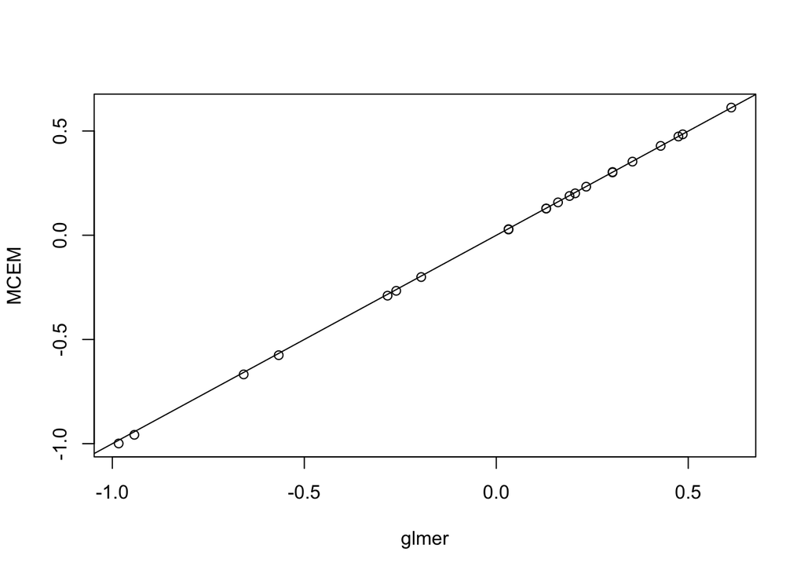

```r
# plot
plot(unlist(ranef(fit)$subject), rowMeans(rejection.samples), xlab = "glmer", ylab = "MCEM", main = "")
abline(0,1)
```

# 4 Markov Chain Monte Carlo

In the last section we discussed Rejection Sampling as a method to directly sample from a target density $f$ when $f$ could be evaluated but not easily sampled from. An alternative way to perform this task are using Markov Chain Monte Carlo (MCMC) methods.

One distinction between Rejection Sampling and MCMC is the latter draws samples only **approximately** from $f$, rather than drawing an exact sample from $f$ itself. MCMC methods can be more generally viewed as methods for generating samples from which expectations of functions of $\boldsymbol{X}$ can be reliably estimated, where $\boldsymbol{X} \sim f(\boldsymbol{X})$.

Another distinction between Rejection Sampling and MCMC is that the latter is **iterative** and can be **flexibly** applied to many different types of problems and situations. If you recall, Rejection Sampling depended on the specification of a proper envelope function, which may or may not be straightforward to do (as could be seen from the homework). Similar concerns could be had about importance sampling regarding the optimal choice of the importance sampling density $g$.

For the purposes of numerical integration, MCMC has several advantages over the methods discussed earlier in this lecture and in the last lecture. The main advantage is that higher dimensional problems do not hinder its application or make its implementation more complex, and it can be flexibly applied to many different situations. However, the samples that are drawn using MCMC, are often **serially correlated**. As a result, estimates based off of these samples often have much greater variance than those based off of independent samples.

## 4.1 Introduction to MCMC methods

Let us define the sequence $\lbrace \boldsymbol{X}^{(t)}\rbrace$ as a Markov chain where $\boldsymbol{X}^{(t)} = \left(X_1^{(t)} ,\ldots ,X_p^{(t)}\right )$, $t = 0, 1, 2,\ldots$, where the state space can be assumed to be either continuous or discrete. We assume that the distribution of $X^{(t)}$ converges to the limiting stationary distribution of the chain when the chain is irreducible and aperiodic. A review of Markov Chain theory is given in GH 1.7.

Briefly, a discrete-state-space Markov chain can be defined as a sequence of random variables $\lbrace \boldsymbol{X}^{(t)}\rbrace$ above, where each ${X}^{(t)}$ can take on a finite or countably infinite number of values called states, where ${X}^{(t)} = j$ indicates that the chain is in state $j$ at step $t$. One hallmark feature of Markov Chains is that the next state in the chain is dependent on only the prior one (the *Markov Property*), such that
$$P[{X}^{(0)},{X}^{(1)},\ldots,{X}^{(M)}] = P[{X}^{(0)}]P[{X}^{(1)}|{X}^{(0)}],\ldots,P[\boldsymbol{X}^{(M)}|\boldsymbol{X}^{(M-1)}].$$
Then, $\lbrace {X}^{(t)}\rbrace$ is a Markov Chain if
$$p_{ij} = P[{X}^{(t+1)} = j | {X}^{(0)} = {x}^{(0)},{X}^{(1)} = {x}^{(1)},\ldots,{X}^{(t)} = i] = P[{X}^{(t+1)} = j | {X}^{(t)} = i]$$
for all $t=0,1,2\ldots$ and states in the state space, where $p_{ij}$ is the one step transition probability (time-homogeneous).

This chain is *irreducible* if the probability that the chain will revisit a previous state in the chain with non-zero probability in a finite number of steps, for all possible states in the chain. That is, regardless of what the current state is in the change, we can revisit any other state in a finite number of steps as the chain runs.

It is *aperiodic* if there is no limitation in terms of the number of steps it takes to revisit a particular state along the chain.

If these two conditions are met, then this chain will converge to some stationary distribution $f$, and the realizations from this chain will be approximately from this distribution for sufficiently large $t$. Then, for any function $h$,
$$\frac{1}{M} \sum_{t = 1}^M h(X^{(t)}) \rightarrow E_f[h(X)]$$
almost surely as $M \rightarrow \infty$. We will see how this will be helpful in MCMC later. **We can similarly extend these ideas to when the state space is continuous (which is typically the case in MCMC).**

The general idea behind MCMC sampling is the construction of an irreducible, aperiodic Markov chain for which the stationary distribution equals the target distribution $f$. Then, a realization $\boldsymbol{X}^{(t)}$ from this chain for large values of $t$ will then have an **approximate** marginal distribution of $f$.

Again, this implies that the samples will be only approximately distributed $f$, and also that subsequent realizations from this chain will clearly be correlated and not independent. We will discuss examples and the implications of this fact later in this lecture.

Therefore, the crux of MCMC lies in the construction of a suitable chain. One natural question when utilizing realizations from the chain is how good the approximation is at a particular $t$. The accuracy of the estimators built off of these realizations will also be impacted by the quality of this approximation.

For example, the distribution of $\boldsymbol{X}^{(t)}$ at small $t$ may differ greatly from $f$, and the chain may not converge to its stationary distribution until $t$ is sufficiently large. In addition, we know that the $\boldsymbol{X}^{(t)}$’s are serially correlated, which may reduce the effective sample size of the realizations being drawn iteratively from the chain.  
In this lecture we will cover some very common and broadly applicable MCMC algorithms, such as Metropolis-Hastings and Gibbs Sampling. In the next lecture, we will cover some specific and more sophisticated MCMC approaches that may be helpful in specific situations.

## 4.2 The Metropolis-Hastings Algorithm

So how do we go about constructing such a chain? One general approach is the Metropolis–Hastings algorithm. The method begins at iteration $t = 0$ with the selection of $\boldsymbol{X}^{(0)} = \boldsymbol{x}^{(0)}$, drawn at random from some distribution $g$ with the requirement that $f(\boldsymbol{x}^{(0)}) > 0$. To generate $\boldsymbol{X}^{(t+1)}$, Metropolis-Hastings uses the following procedure:

1. Sample a candidate value $\boldsymbol{X}^{*}$ from a proposal distribution $g(\cdot | \boldsymbol{x}^{(t)})$
2. Compute the Metropolis–Hastings ratio $R(\boldsymbol{x}^{(t)},\boldsymbol{X}^{*})$ where

$$R(\boldsymbol{x}^{(t)}, \boldsymbol{X}^{*}) = \frac{f(\boldsymbol{X}^{*})g(\boldsymbol{x}^{(t)}| \boldsymbol{X}^{*})}{f(\boldsymbol{x}^{(t)})g(\boldsymbol{X}^{*}| \boldsymbol{x}^{(t)})}.$$
This ratio is always defined because we can only generate the proposal $\boldsymbol{X}^{*} = \boldsymbol{x}^{*}$ to begin with if $f(\boldsymbol{x}^{(0)}) > 0$ and $g( \boldsymbol{x}^{*} | \boldsymbol{x}^{(t)})>0$. Then, we pick the new value for $\boldsymbol{X}^{(t+1)}$ such that

$$\begin{align}
\boldsymbol{X}^{(t+1)} &= \begin{cases}
\boldsymbol{X}^{*} \text{ with probability min} (R(\boldsymbol{x}^{(t)},\boldsymbol{X}^{*}),1)\\
\boldsymbol{x}^{(t)} \text{ otherwise.}
\end{cases}
\end{align}$$

In other words, we keep $\boldsymbol{X}^{*}$ as our next sample with probability 1 if $R(\boldsymbol{x}^{(t)},\boldsymbol{X}^{*}) > 1$, otherwise we keep it with probability $R(\boldsymbol{x}^{(t)},\boldsymbol{X}^{*})$. If $\boldsymbol{X}^{*}$ is not kept, we simply set $\boldsymbol{X}^{(t+1)}$ equal to the prior value in the chain $\boldsymbol{x}^{(t)}$.

4. Set $t = t+1$ and return to step 1.

If the proposal density $g$ is symmetric such that $g( \boldsymbol{x}^{*} | \boldsymbol{x}^{(t)}) = g( \boldsymbol{x}^{(t)} | \boldsymbol{x}^{*})$, Metropolis Hastings reduces to what is known as the Metropolis algorithm, where $R(\boldsymbol{x}^{(t)}, \boldsymbol{X}^{*}) = \frac{f(\boldsymbol{X}^{*})}{f(\boldsymbol{x}^{(t)})}.$

### 4.2.1 Chain Convergence

Since $\boldsymbol{X}^{(t+1)}$ is only dependent on $\boldsymbol{X}^{(t)}$, the chain constructed via the procedure above is clearly a markov chain. However, whether this chain is also irreducible and aperiodic is dependent on $g$, and one must check these conditions for any implementation (we will talk about how to do this later). If these conditions are met, the marginal distribution of $\boldsymbol{x}^{(t+1)}$ is $f$, and $f$ is the stationary distribution of the chain.

Assuming that these conditions are met and that the chain has converged, what do we do with the samples obtained from such a chain? The distribution of realizations from the Metropolis–Hastings chain approximates the stationary distribution of the chain as $t$ progresses, and therefore $E[h(X)] \approx (1/M) \sum_{k = 1}^M h(\boldsymbol{x}^{(k)})$. Estimates of such quantities based on sample averages in this setting are strongly consistent.

Based on how the chain is constructed in MH, $\boldsymbol{x}^{(0)},\ldots,\boldsymbol{x}^{(M)}$ will likely include sequentially repeated values in the chain from when $\boldsymbol{X}^{(t+1)}$ retains its previous value $\boldsymbol{x}^{(t)}$. These repeats must be kept in the chain when computing the approximations above as they correct for the fact that the proposal density differs from the target density.

### 4.2.2 Chain Starting Points and Burn in Period

The chain itself may take some time to converge to its stationary distribution, and samples drawn from early portions of the chain will not closely approximate $f$. Therefore, the removal of initial realizations from the chain is typically done before computing the aprpoximation for $E[h(X)]$. This initial sequence that is removed is called the **burn-in period**, and is an essential component of MCMC.

For example, you can imagine that if you start a chain at a “bad” point, it may take longer for the chain to converge to its stationary distribution. The realizations drawn along the way are not from this stationary distribution, and therefore should be discarded as part of the burn in. As we will see, the persistent dependence of the chain on its starting point can seriously hamper its performance.

Just like with the optimization methods discussed earlier in this module, it is often good to run any MCMC procedure (such as MH) from multiple starting points to check for consistent results. We will discuss some practical aspects regarding burn-in, number of chains, starting values, and other aspects of MCMC implementation later on in this lecture.

### 4.2.3 Features of a “Good” Proposal Distribution

Specific features of a good proposal distribution $g$ such as the following can greatly enhance the performance of the Metropolis–Hastings algorithm:

1. $g$ covers the support of the stationary distribution in a reasonable number of iterations, and
2. produces candidate values that are not accepted or rejected too frequently

A proposal distribution whose spread is either too small/large can produce a chain that requires many iterations to adequately sample the regions supported by the target distribution.

That is, if the proposal distribution has too narrow of a spread, it will stay localized in a specific region of the support and will take a long time to explore other regions.

If its spread it too broad, candidate values will be rejected frequently and will also take longer to adequately explore the space of the target distribution. We will discuss how to practically choose a good proposal distribution in a later section.

So how exactly do we create such chain with MH? We discuss two variants of MH below, each characterized by the class of proposal distributions that they utilize.

### 4.2.4 Independence Chains

Suppose that the proposal distribution for MH is chosen such that $g(\boldsymbol{x}^{*} | \boldsymbol{x}^{(t)})= g(\boldsymbol{x}^{*})$. Then this gives what is called an **independence chain**, where each candidate value is drawn independently of the prior realizations of the chain. As a result, the MH ratio simplifies to
$$R(\boldsymbol{x}^{(t)}, \boldsymbol{X}^{*}) = \frac{f(\boldsymbol{X}^{*})g(\boldsymbol{x}^{(t)})}{f(\boldsymbol{x}^{(t)})g(\boldsymbol{X}^{*})}.$$
which produces an irreducible and aperiodic chain if $g( \boldsymbol{x}) > 0$ whenever $f( \boldsymbol{x}) > 0$.

Again, the idea here is that we generate a chain long enough such that the realizations from this chain, at sufficiently large $t$, are approximately distributed $f$.

This is in contrast to Rejection Sampling where we are directly sampling from $f$ using the described procedure. However, the downside is that we have to construct a proper envelope function.

With MCMC the approach is more general, where we specify the proposal distribution and afterwards check diagnostics regarding the chain.

One interesting thing to note is that the MH ratio can be interpreted as a ratio of importance weights, where if $w^∗ = f(X^∗)/g(X^∗)$ and $w^{(t)} = f(x^{(t)})/g(x^{(t)})$, then $R(x^{(t)},X^∗)= w^∗/w^{(t)}$. This suggests that if the prior draw results in a larger than usual $w^{(t)}$ than typical $w^∗$ values, the chain may get stuck for a while at $x^{(t)}$ (large denominator –> small ratio –> low acceptance probability of new proposals).

As a result, the criteria for choosing importance sampling distributions are also relevant to choosing good proposal distributions. We will talk more about this after some of the following code examples.

### 4.2.5 Example: Bayesian Inference in mixture models

MCMC methods are popular tools for Bayesian inference, where some data $\boldsymbol{y}$ are observed with likelihood $L(\boldsymbol{\theta}|\boldsymbol{y})$ for parameters $\boldsymbol{\theta}$ which have prior distribution $p(\boldsymbol{\theta})$. Bayesian inference is often based off of the posterior distribution $p(\boldsymbol{\theta}|\boldsymbol{y}) \propto cp(\boldsymbol{\theta})L(\boldsymbol{\theta}|\boldsymbol{\y})$, where $c$ is an unknown constant.

The difficulty of computing $c$ and other features of the posterior prevents most direct inferential strategies. However, if we can obtain a sample from a Markov chain whose stationary distribution is the target posterior, these samples can be used to estimate many quantities such as posterior means and variances, tail probabilities and even the posterior density itself.

A very simple strategy is to use the prior as a proposal distribution in an independence chain, as this prior should cover the support of the support of the posterior. In our Metropolis–Hastings notation, $f(\boldsymbol{\theta}) = p(\boldsymbol{\theta}|\boldsymbol{y})$ and $g(\boldsymbol{\theta}^∗) = p(\boldsymbol{\theta}^∗)$.

Conveniently, this means that $R(\boldsymbol{\theta}^{(t)}, \boldsymbol{\theta}^∗) = \frac{L(\boldsymbol{\theta}^*, \boldsymbol{y})}{L(\boldsymbol{\theta}^{(t)}, \boldsymbol{y})}$, where the priors $p$ cancel out with the proposal distributions $g$ in the numerator and denominator.

In other words, we propose from the prior, and the Metropolis–Hastings ratio equals the likelihood ratio. Therefore, we accept a proposal with probability 1 if the proposal improves the likelihood relative to the previous realization. Otherwise, we accept the proposal with probability equal to the ratio if it is less than 1.

By repeating this process a large number of times, the chain will hopefully converge to the target distribution $f$. By definition, the support of the prior covers the support of the target posterior, so the stationary distribution of this chain is the desired posterior.

Suppose we have observed data from GH Example 7.2, where observations $y_1, y_2,\ldots,y_{100}$ are sampled iid from the mixture distribution
$$f(y | \boldsymbol{\mu}, \sigma^2) = \pi f(y| \mu_1, \sigma^2) + (1-\pi)f(y| \mu_2, \sigma^2).$$
Here $\boldsymbol{\mu} = (\mu_1, \mu_2) = (7, 10)$, $\sigma^2 = 0.5^2$, and $\pi = 0.7$.

We will use a MH independence sampler to construct a chain whose stationary distribution equals the posterior density of $\pi$, assuming $\pi \sim U(0,1)$ as a non-informative prior distribution. Therefore, we would expect the posterior mean for $\pi$ to be concentrated in the area around 0.7.

Let’s read in and visualize the data from GH Example 7.2 below:

```r
## Read in the data
mixture = read.table("mixture.dat",header=TRUE)

## Examine dimensions of dataset
dim(mixture)
```

```
## [1] 100   1
```

```r
## Peek at Data
head(mixture)
```

```
##          y
## 1 7.253252
## 2 6.856523
## 3 7.236438
## 4 7.033436
## 5 6.918659
## 6 6.656499
```

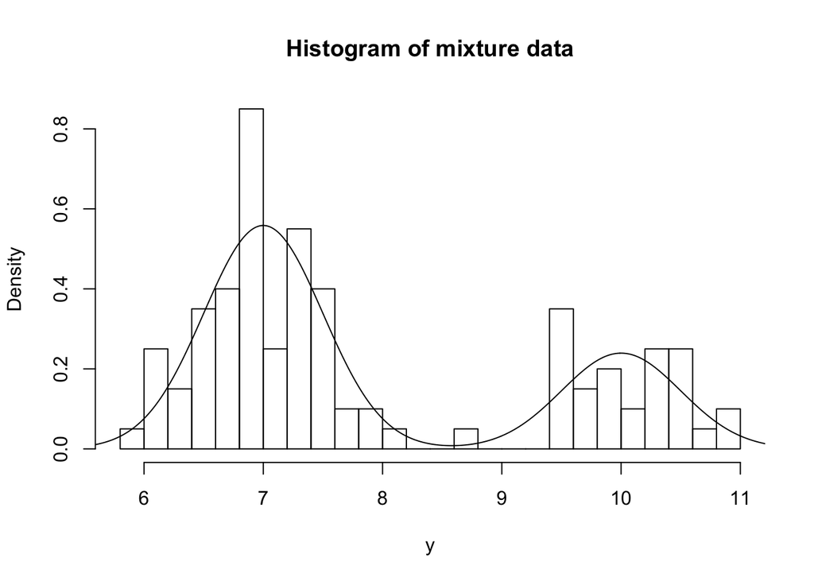

```r
## Make a histogram of the responses
# extract y
y = mixture$y

# define range for plotting
x = seq(5, 14, by = 0.01)

# get density values for mixture given true values
d = 0.7*dnorm(x, mean = 7,sd =  0.5) + 0.3*dnorm(x,mean =  10,sd =  0.5)

# plot histogram and overlay density
hist(y,breaks=20,freq=FALSE,main="Histogram of mixture data",ylab="Density")
points(x,d,type="l")
```

In the first case we use a Beta(1,1) density as the proposal density. This is equivalent to the U(0,1) density, which is the assumed prior on $\pi$. Let’s start by setting up some helper functions:

```r
# function for the mixture likelihood
# note that since the prior is uniform it is not specified in f below (enters as a constant)
f = function(x,y){
  prod(x*dnorm(y,7,0.5) + (1-x)*dnorm(y,10,0.5))
}

# beta(1,1) proposal density function for pi
g = function(x){
  dbeta(x,1,1)
}

# proposal function
g.sim = function(){
  rbeta(1,1,1)
}

# Define MH ratio function given f and g, x is the proposal, xt is the current value from the chain
# note that we specify g here just for completeness (it cancels out with the uniform prior as mentioned earlier)
R = function(xt,x, f, g, y){
  f(x,y)*g(xt)/(f(xt,y)*g(x))
}
```

Now that thats done, let’s start the MH algorithm:

```r
# set the seed
set.seed(0)

# Set chain length
M = 10000

# initialize the chain vector
x.indep.chain = rep(0,M)

# Simulate initial draw from proposal density beta(1, 1)
x.indep.chain[1] = g.sim()

# now start chain
for(i in 1:M){

  # set the value at current iteration of the chain to variable xt
  xt = x.indep.chain[i]

  # draw a proposal from the proposal density
  x = g.sim()

  # calculate MH ratio
  r = min(R(xt, x, f, g, y),1)

  # Generate draw from bernoulli(p).
  # Alternatively, can directly compare ratio to
  # a U(0,1) draw as we did with Rejection Sampling
  keep = rbinom(1, 1, r)

  # if keep = 1, then set next iteration equal to then proposal
  if(keep == 1){
    x.indep.chain[i+1] = x
  }else{
    # otherwise, carry over value from the current iteration
    x.indep.chain[i+1] = xt
  }
}

# save result for later diagnostics
x.indep.chain.good = x.indep.chain
```

Now let’s take a look at the some of the characteristics of the chain. Let’s first make a “sample path” plot of the chain to see how it looks across iterations. Then let’s make a histogram of the values

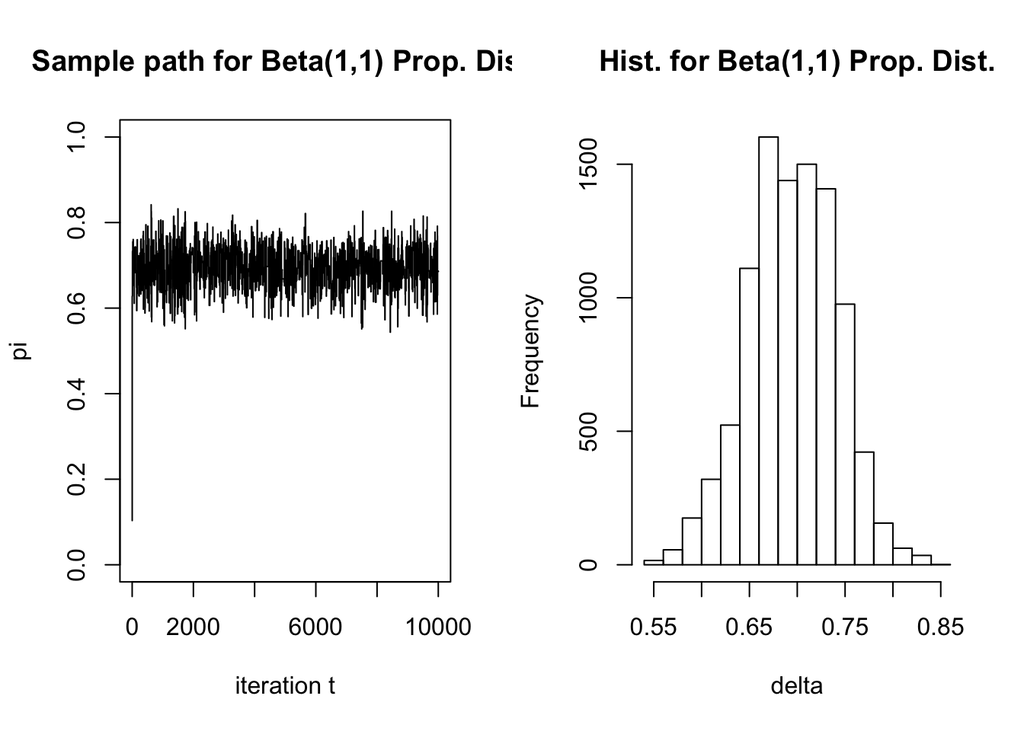

```r
par(mfrow=c(1,2))
# Sample Path
plot(x.indep.chain, ylim=c(0,1), type="l",
     ylab="pi", xlab="iteration t",
     main = "Sample path for Beta(1,1) Prop. Dist.")

# Histogram
hist(x.indep.chain[201:(M+1)],breaks=20,xlab="delta",
     main="Hist. for Beta(1,1) Prop. Dist.")
```

The sample path plot shows each of the chain realizations $\pi^{(t)}$ with respect to the iteration number $t$. We see that the markov chain quickly moves away from its starting point and seems easily able to sample values from all portions of the parameter space supported by the posterior for $\pi$. Such behavior is called **good mixing**.

We can easily see that the chain has converged to its stationary distribution (no trends observed, random variability). In the histogram we drop the first 200 iterations of the chain to reduce the effect of the starting value. We can see right away that the chain produced a sample for $\pi$ whose mean well-approximates the true posterior mean of $\pi = 0.7$ (since the prior is non-informative being equivalent to U(0,1)).

Let’s now explore the impact of using an alternative proposal distribution, a Beta(2,10) density. The first proposal distribution is equivalent to a U(0,1) distribution, while this one is skewed rightwards with mean approximately equal to 0.167. In this case, values of $\pi$ near 0.7 are unlikely to be generated from the proposal distribution. Therefore, we do not expect the proposal distribution to cover well the entire support of the posterior. Let’s go ahead and run the MH algorithm using this proposal density:

```r
# update helper functions for new prop
g = function(x){
  dbeta(x,2,10)
}

g.sim = function(){
  rbeta(1,2,10)
}

# initialize chain
x.indep.chain = rep(0, M)

# simulate initial draw from proposal density beta(2, 10)
x.indep.chain[1] = g.sim()

# now start chain
for(i in 1:M){

  # save the prior state of chain at step t to xt
  xt = x.indep.chain[i]

  # draw from the proposal density
  x = g.sim()

  # calculate MH ratio
  r = min(R(xt, x, f, g, y),1)

  # Generate draw from bernoulli(p)
  keep = rbinom(1, 1, r)

  # if keep = 1, then update next state with draw
  if(keep == 1){
    x.indep.chain[i+1] = x
  }else{
    # otherwise, carry over value from prior iteration
    x.indep.chain[i+1] = xt
  }
}

# save result for later
x.indep.chain.bad = x.indep.chain
```

Now let’s remake the same plots:

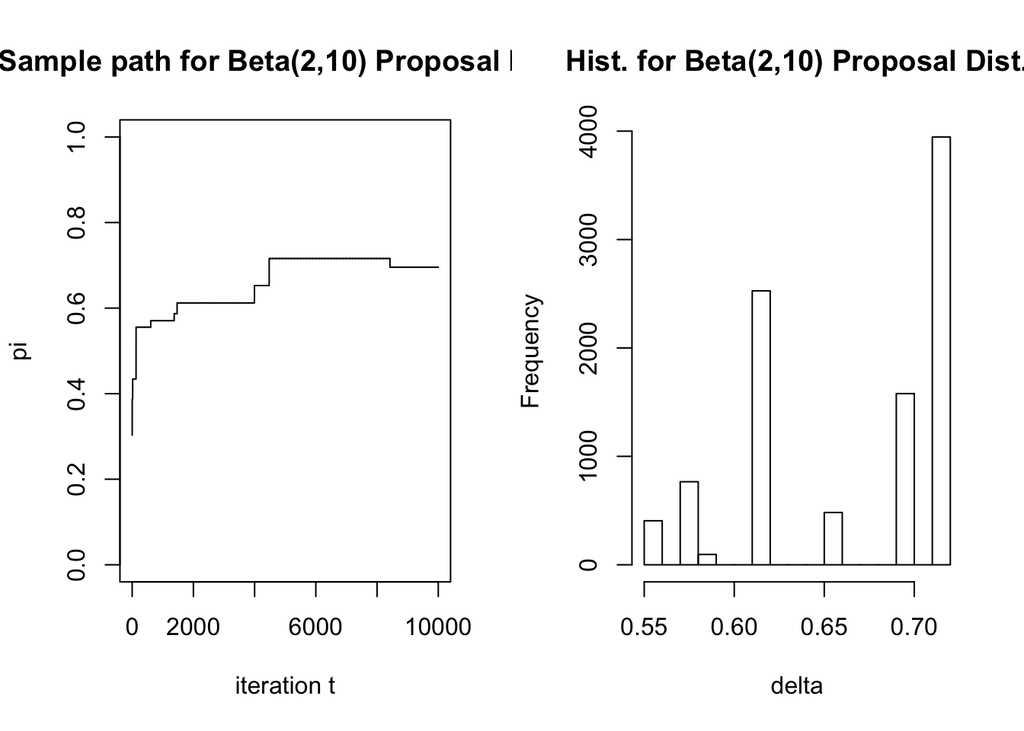

```r
par(mfrow=c(1,2))
# Sample Path
plot(x.indep.chain, ylim=c(0,1), type="l",
     ylab="pi", xlab="iteration t",
     main = "Sample path for Beta(2,10) Proposal Dist.")

# Histogram
hist(x.indep.chain[201:(M+1)],breaks=20,xlab="delta",
     main="Hist. for Beta(2,10) Proposal Dist.")
```

We can see that the resulting chain moves slowly from its starting value and does a poor job of exploring the region of posterior support (**poor mixing**) in the first 10,000 iterations. This chain has clearly not converged to its stationary distribution since drift is still apparent.

The flat areas in the sample path plots are those where the proposals were not accepted for many iterations in a row, a result of the poor proposal distribution. This also increases the autocorrelation among subsequent realizations of the chain. Later we will talk in more detail regarding chain diagnostics.

In principle, for very large $t$ we will still be able to estimate aspects of the posterior for $\pi$ since the posterior is still the limiting distribution of the chain. Yet, chain behavior like that shown here does not inspire confidence for finite $t$: The chain seems nonstationary, only a few unique values of $\pi^{(t)}$ were accepted, and the starting value does not appear to have washed out.

A plot like this should make the user reconsider the proposal density and other aspects of the MCMC implementation. Based on the first 10,000 iteration, this chain would not yield reliable estimates for the posterior.